# Advanced Data Visualization

Joshua F. Wiley/Pei Hwa Goh/Michelle Byrne

2022-03-05

```r
options(digits = 3)

## load relevant packages
library(tufte)
library(haven)
library(data.table)
library(JWileymisc)
library(psych)
```

```r
library(ggplot2)
library(ggpubr)
library(ggthemes)
library(scales)
library(ggExtra)

## turn off some notes from R in the final HTML document
knitr::opts_chunk$set(message = FALSE)
```

This reading is entirely optional for PSY4210.

# 1 Plotting Clinical Data

Next, we are going to look at some hypothetical data from an intervention comparing augmented Treatment as Usual (TAU+) to Cognitive Behavioural Therapy (CBT+). The two conditions are measured at baseline and post intervention on depression symptoms. The first part of the code just simulates some data including a wide dataset, `trial` and a long dataset, `trial2`. **You do not need to follow this code, it is just to get us some sample data to work with.**

```r
## code to make an example dataset
set.seed(1234)
trial <- data.table(
  ID = sample(1:70),
  Group = factor(rep(c("TAU+", "CBT+"), each = 35)),
  B_Dep = pmax(round(rnorm(35*2, mean = 22, sd = 7)), 0))
trial[, P_Dep := round(B_Dep * rnorm(70, mean = ifelse(Group == "CBT+", .5, .9), sd = .2))]
trial2 <- reshape(trial, varying = list(c("B_Dep", "P_Dep")), v.names = "Depression",
                 timevar = "Assessment", times = c(0, 1),
                 idvar = "ID", direction = "long")

head(trial)
```

```
##    ID Group B_Dep P_Dep
## 1: 28  TAU+    15    16
## 2: 22  TAU+    21    27
## 3:  9  TAU+    26    24
## 4:  5  TAU+    34    26
## 5: 38  TAU+    17    10
## 6: 16  TAU+    33    26
```

```r
head(trial2)
```

```
##    ID Group Assessment Depression
## 1: 28  TAU+          0         15
## 2: 22  TAU+          0         21
## 3:  9  TAU+          0         26
## 4:  5  TAU+          0         34
## 5: 38  TAU+          0         17
## 6: 16  TAU+          0         33
```

With some sample data, we can plot the long dataset to show the mean and confidence intervals for each group at each time point.

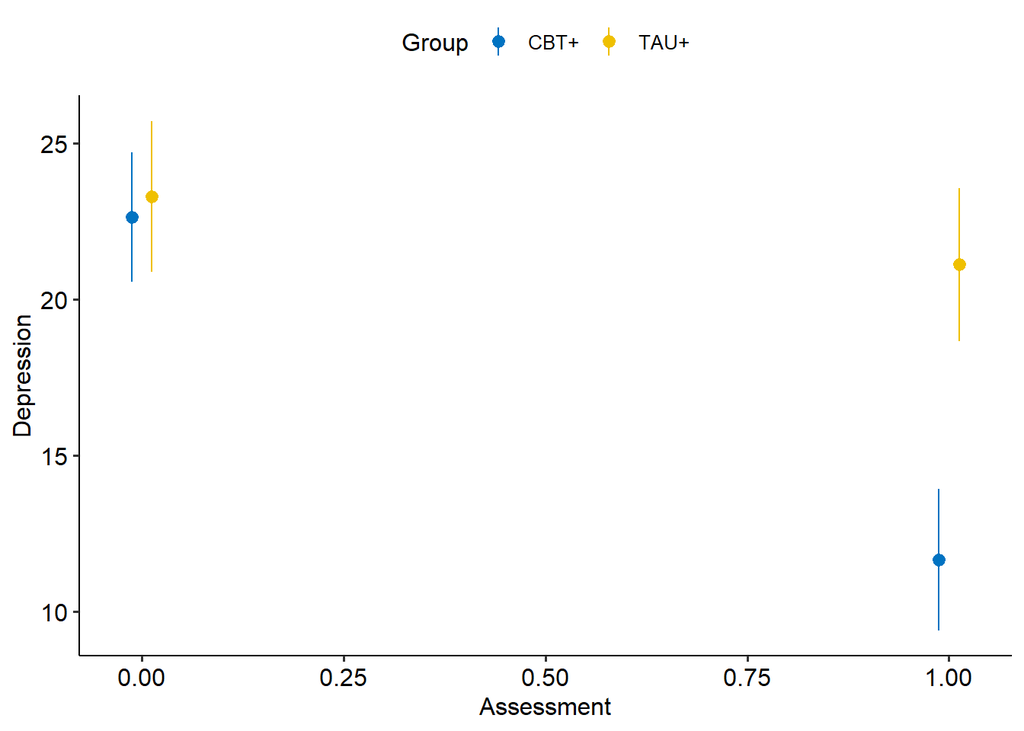

```r
p.trial1 <- ggplot(trial2, aes(Assessment, Depression, colour = Group)) +
  stat_summary(fun.data = mean_cl_normal,
               position = position_dodge(.05),
               geom = "pointrange") +
  theme_pubr()
p.trial1 <- set_palette(p.trial1, palette = "jco")

print(p.trial1)
```

Because these are longitudinal data, it makes sense to connect them with lines to show how they changed over time. We do this by adding a line geom based on the mean. Then we tidy up the x axis labels and the y axis labels.

Finally, something new, we use `geom_hline()` to add a horizontal line at 16, a common cut off on the CES-D indicative of clinically significant depression symptoms. We make this a dashed, grey line to make it less prominent. This line aids interpretation by helping people anchor the results to common cut offs. We also use the `coord_cartesian()` function to change the limits of the graph. Since the CES-D scale starts at 0 (meaning lowest possilbe / no depression symptoms) we make that the y axis limit. The x axis limits are based on the coding of assessments and the upper y axis limit we base visually off the upper confidence interval.

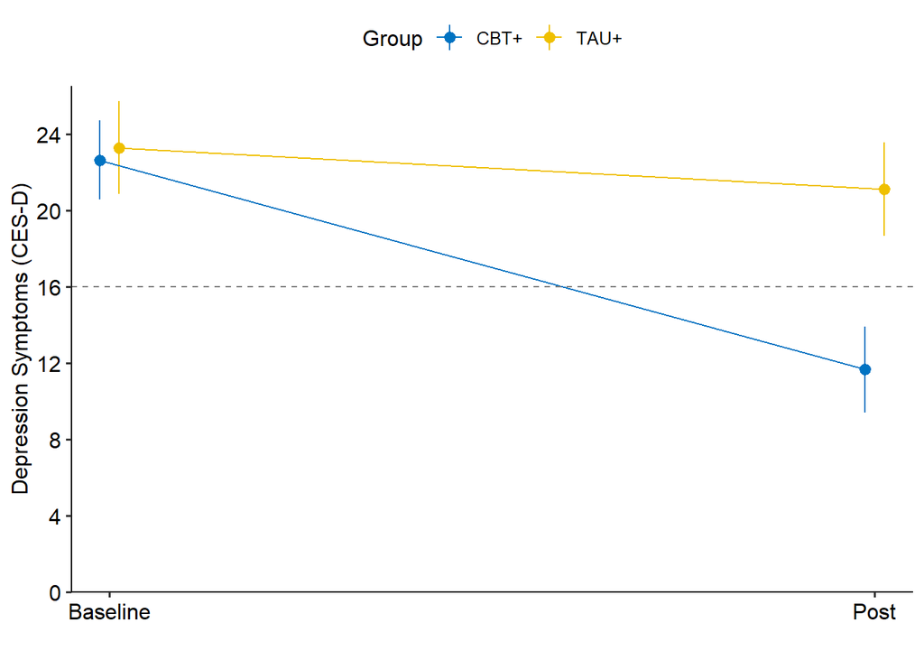

```r
p.trial1b <- p.trial1 +
  stat_summary(fun = mean,
               position = position_dodge(.05),
               geom = "line") +
  scale_x_continuous("",
                     breaks = c(0, 1),
                     labels = c("Baseline", "Post")) +
  scale_y_continuous("Depression Symptoms (CES-D)",
                     breaks = c(0, 4, 8, 12, 16, 20, 24)) +
  geom_hline(yintercept = 16, linetype = 2, colour = "grey50") +
  coord_cartesian(xlim = c(-.05, 1.05), ylim = c(0, 26.5), expand = FALSE)

print(p.trial1b)
```

The other information that would be useful would be to annotate with information about group differences and change over time. First we run a regression on depression by group at each time point and then use those p-values to add annotations to the graph.

```r
summary(lm(Depression ~ Group,
        data = trial2[Assessment == 0]))
```

```
##
## Call:
## lm(formula = Depression ~ Group, data = trial2[Assessment ==
##     0])
##
## Residuals:
##     Min      1Q  Median      3Q     Max
## -11.286  -4.286  -0.629   3.714  16.714
##
## Coefficients:
##             Estimate Std. Error t value Pr(>|t|)
## (Intercept)   22.629      1.109   20.40   <2e-16 ***
## GroupTAU+      0.657      1.569    0.42     0.68
## ---
## Signif. codes:  0 '***' 0.001 '**' 0.01 '*' 0.05 '.' 0.1 ' ' 1
##
## Residual standard error: 6.56 on 68 degrees of freedom
## Multiple R-squared:  0.00257,    Adjusted R-squared:  -0.0121
## F-statistic: 0.175 on 1 and 68 DF,  p-value: 0.677
```

```r
summary(lm(Depression ~ Group,
        data = trial2[Assessment == 1]))
```

```
##
## Call:
## lm(formula = Depression ~ Group, data = trial2[Assessment ==
##     1])
##
## Residuals:
##     Min      1Q  Median      3Q     Max
## -12.657  -4.657  -0.886   3.229  17.343
##
## Coefficients:
##             Estimate Std. Error t value Pr(>|t|)
## (Intercept)    11.66       1.16   10.05  4.5e-15 ***
## GroupTAU+       9.46       1.64    5.76  2.2e-07 ***
## ---
## Signif. codes:  0 '***' 0.001 '**' 0.01 '*' 0.05 '.' 0.1 ' ' 1
##
## Residual standard error: 6.86 on 68 degrees of freedom
## Multiple R-squared:  0.328,  Adjusted R-squared:  0.318
## F-statistic: 33.2 on 1 and 68 DF,  p-value: 2.19e-07
```

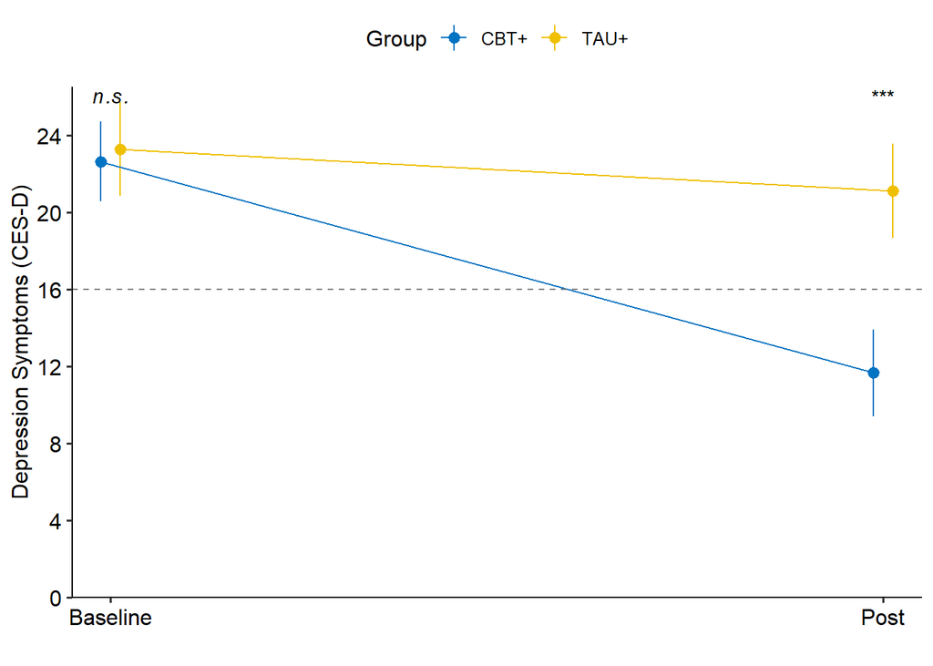

```r
p.trial1b +
  annotate("text", x = 0, y = 26, label = "italic(n.s.)", parse = TRUE) +
  annotate("text", x = 1, y = 26, label = "***")
```

In smaller datasets we could visualize the individual changes in depression symptoms. We again plot depression symptoms on the y axis, assessment on the x axis and colour by group, but instead of summarizing the data, we directly plot points and lines. We use the `group = ID` to indicate we want a different line for each ID in the dataset.

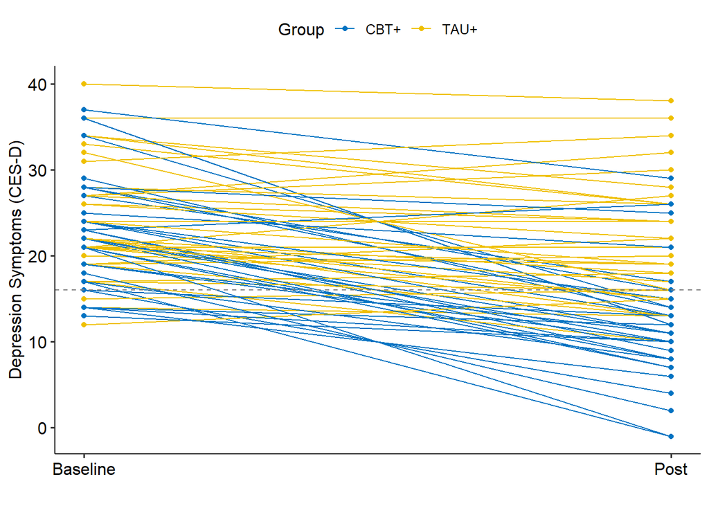

```r
p.trial2 <- ggplot(trial2, aes(Assessment, Depression, colour = Group, group = ID)) +
  geom_line() +
  geom_point() +
  scale_x_continuous("",
                     breaks = c(0, 1),
                     labels = c("Baseline", "Post")) +
  scale_y_continuous("Depression Symptoms (CES-D)") +
  geom_hline(yintercept = 16, linetype = 2, colour = "grey50") +
  theme_pubr()
p.trial2 <- set_palette(p.trial2, "jco")

print(p.trial2)
```

The result lets us see the starting point and change over time for each person, but its a bit messy. Rather than just colour by group, it might be helpful to separate by group, which we do by facetting.

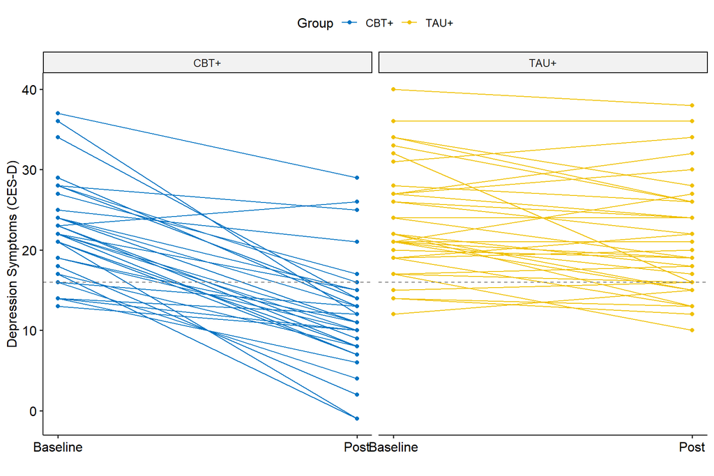

```r
p.trial2 + facet_grid(. ~ Group)
```

That worked, but now our labels overlap. We need to add some space between each facet (panel). Since each panel is labelled, we do not really need the legend guide for group, so we turn that off by using the `guides()` function to clean the plot up a bit.

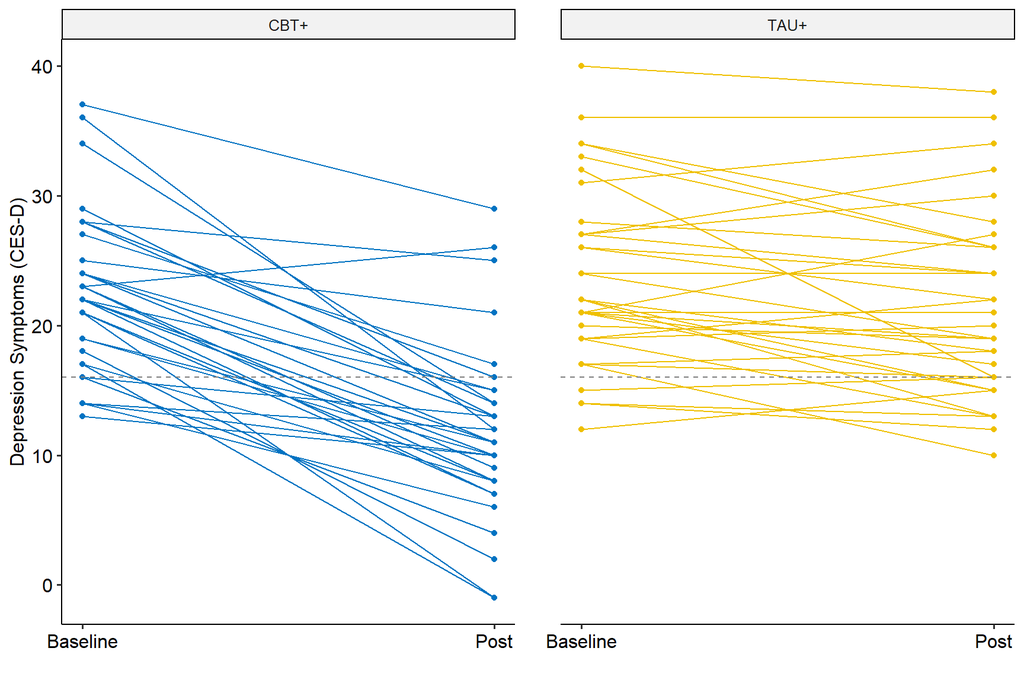

```r
p.trial2 + facet_grid(. ~ Group) +
  theme(panel.spacing = unit(2, "lines")) +
  guides(colour = "none")
```

Another way to show individual change would be to use the wide dataset to calculate individual change scores. A common approach is to examine the percent change. We subtract 1 so that 0 means no change. To plot the results, we put the individual IDs on the x axis and the height of the bars is the percent change.

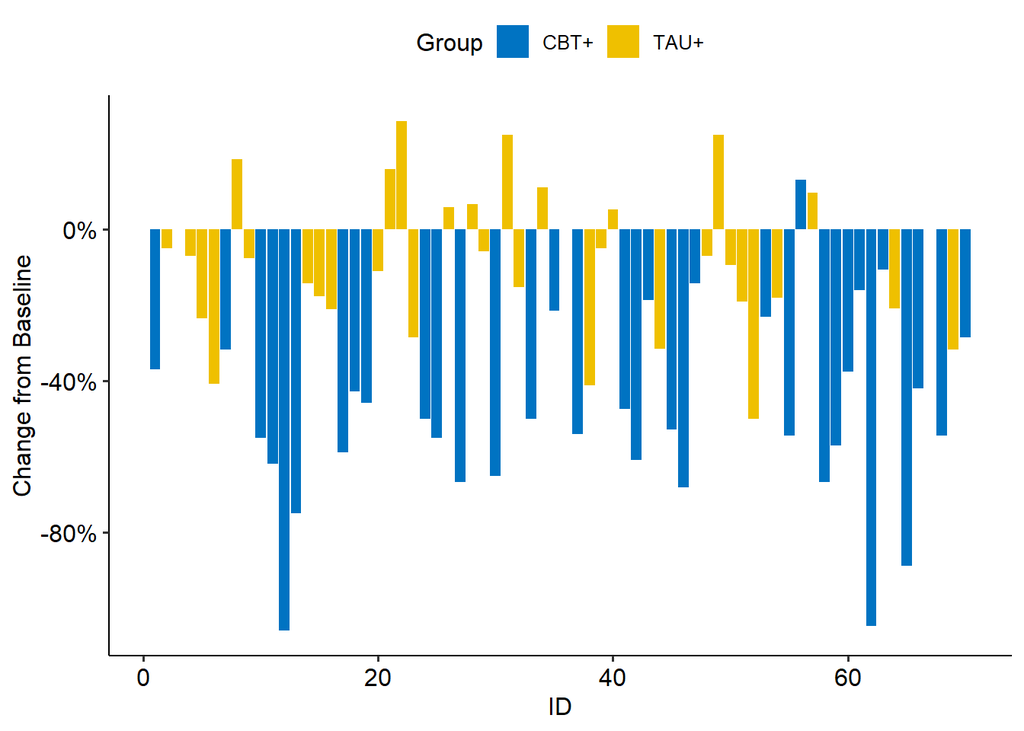

```r
trial[, PercentChange := P_Dep/B_Dep - 1]

p.trial3 <- ggplot(trial, aes(ID, PercentChange, fill = Group)) +
  geom_bar(stat = "identity") +
  theme_pubr() +
  scale_y_continuous("Change from Baseline", labels = percent)

p.trial3 <- set_palette(p.trial3, "jco")

print(p.trial3)
```

Although this figure is technically accurate, it is difficult to interpret. The general pattern seems to be that the CBT+ group has a more negative change. Ordering the data can improve this. We use the `order()` function to order by percent change and then order that to get numbers for a “new” ID variable. Now we can remake the plot, with a few other tweaks to clean it up (a line at 0, no change, removing the x axis and adding a better x axis title).

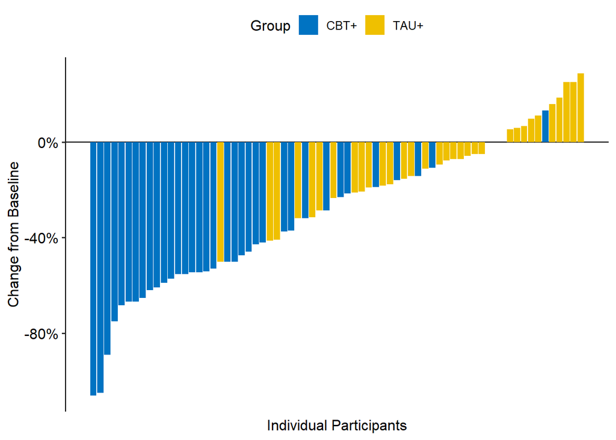

```r
trial[, ID2 := order(order(PercentChange))]

p.trial4 <- ggplot(trial, aes(ID2, PercentChange, fill = Group)) +
  geom_hline(yintercept = 0) +
  geom_bar(stat = "identity") +
  theme_pubr() +
  scale_y_continuous("Change from Baseline", labels = percent) +
  xlab("Individual Participants") +
  theme(
    axis.line.x = element_blank(),
    axis.ticks.x = element_blank(),
    axis.text.x = element_blank())

p.trial4 <- set_palette(p.trial4, "jco")

print(p.trial4)
```

With the data ordered, it is much easier to see the biggest decline, the biggest increase and to see that the CBT+ group dominates the left hand side with the largest decreases while little decrease or even increases occur almost exclusively in the TAU+ group.

If we wanted a slight modification is to order first by group and then by percent change, giving the followiing result.

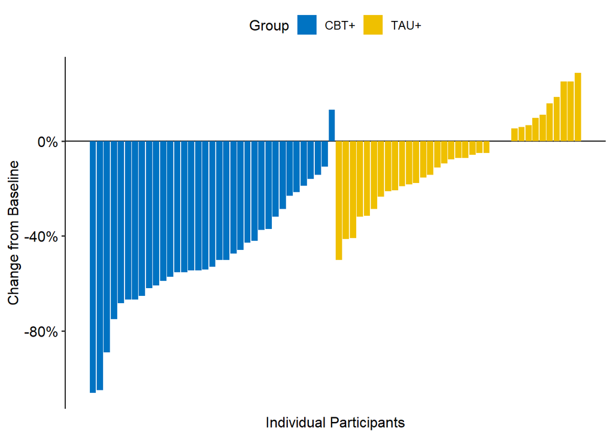

```r
trial[, ID3 := order(order(Group, PercentChange))]

p.trial5 <- ggplot(trial, aes(ID3, PercentChange, fill = Group)) +
  geom_hline(yintercept = 0) +
  geom_bar(stat = "identity") +
  theme_pubr() +
  scale_y_continuous("Change from Baseline", labels = percent) +
  xlab("Individual Participants") +
  theme(
    axis.line.x = element_blank(),
    axis.ticks.x = element_blank(),
    axis.text.x = element_blank())

p.trial5 <- set_palette(p.trial5, "jco")

print(p.trial5)
```

# 2 Summary Table

Here is a little summary of some of the functions used in this topic. You might also enjoy this “cheatsheet” for `ggplot2`: https://github.com/rstudio/cheatsheets/raw/master/data-visualization-2.1.pdf

| Function | What it does |
| --- | --- |
| `ggplot()` | Sets the dataset and which variables map to which aesthetics for a plot |
| `geom_point()` | Adds points such as for a scatter plot |
| `geom_hline()` | Adds a horizontal line at a specific y axis value |
| `stat_summary()` | Used to automatically calculate some summary statistics on data and plot, usually means with standard errors or confidence intervals |
| `stat_smooth()` | Used to automatically calculate a regression line |
| `ylab()` | Adds a label for the y axis |
| `xlab()` | Adds a label for the x axis |
| `theme_pubr()` | A cleaner black and white theme for `ggplot2` |